# Dimensionality reduction techniques

The Human Development Index (HDI) dataset originates from the United Nations Development Programme.  
The Human Development Index (HDI) is a summary measure of average achievement in key dimensions of human development: a long and healthy life, being knowledgeable and have a decent standard of living.  
The HDI is the geometric mean of normalized indices for each of the three dimensions.

“Country” = Country name  
“GNI” = Gross National Income per capita  
“LifeExp” = Life expectancy at birth  
“EdExp” = Expected years of schooling  
“MatMortality” = Maternal mortality ratio  
“TeenBirthRate” = Adolescent birth rate  
“ParlPerc” = Percent.Representation.in.Parliament  
“edu_ratio” = Edu2_f / Edu2_m  
“lab_ratio” = Labo2_f / Labo2_m

```r
human <- read.csv("./data/human.csv", sep=",", dec = ".", row.names = 1)
summary (human)
```

```
##    edu_ratio        lab_ratio          EdExp          LifeExp
##  Min.   :0.1717   Min.   :0.1857   Min.   : 5.40   Min.   :49.00
##  1st Qu.:0.7264   1st Qu.:0.5984   1st Qu.:11.25   1st Qu.:66.30
##  Median :0.9375   Median :0.7535   Median :13.50   Median :74.20
##  Mean   :0.8529   Mean   :0.7074   Mean   :13.18   Mean   :71.65
##  3rd Qu.:0.9968   3rd Qu.:0.8535   3rd Qu.:15.20   3rd Qu.:77.25
##  Max.   :1.4967   Max.   :1.0380   Max.   :20.20   Max.   :83.50
##       GNI          MatMortality    TeenBirthRate       ParlPerc
##  Min.   :   581   Min.   :   1.0   Min.   :  0.60   Min.   : 0.00
##  1st Qu.:  4198   1st Qu.:  11.5   1st Qu.: 12.65   1st Qu.:12.40
##  Median : 12040   Median :  49.0   Median : 33.60   Median :19.30
##  Mean   : 17628   Mean   : 149.1   Mean   : 47.16   Mean   :20.91
##  3rd Qu.: 24512   3rd Qu.: 190.0   3rd Qu.: 71.95   3rd Qu.:27.95
##  Max.   :123124   Max.   :1100.0   Max.   :204.80   Max.   :57.50
```

## Graphical overview of the data

```r
library(GGally)
```

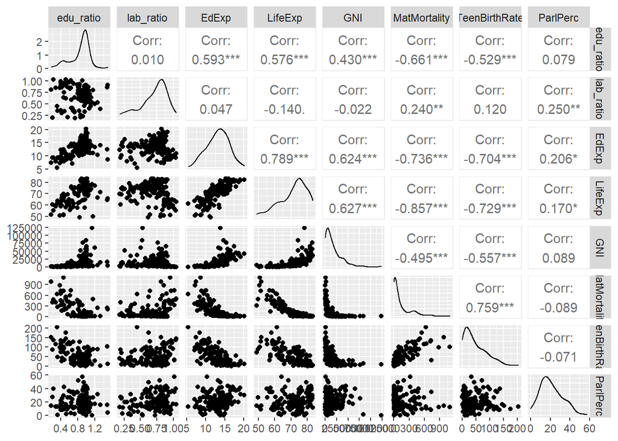

```r
library(ggplot2)
library(dplyr)
pairs <- ggpairs(human, mapping = aes(), lower = list(combo = wrap("facethist", bins = 20)))
pairs
```

In the pairs plots we see that some of the variables are approximately normally distributed (e.g. EdExp: expected years of schooling), while the distribution of other variables is somewhat skewed. Two of them, GNI per capita and maternal mortality are significantly skewed to the right, meaning that most of the values in these variables are low. The ratio of females and males with at least secondary education, expected years of schooling, life expectancy at birth, and Gross National Income per capita are all positively correlated with each other, and negatively correlated with maternal mortality ratio and adolescent birth rate.

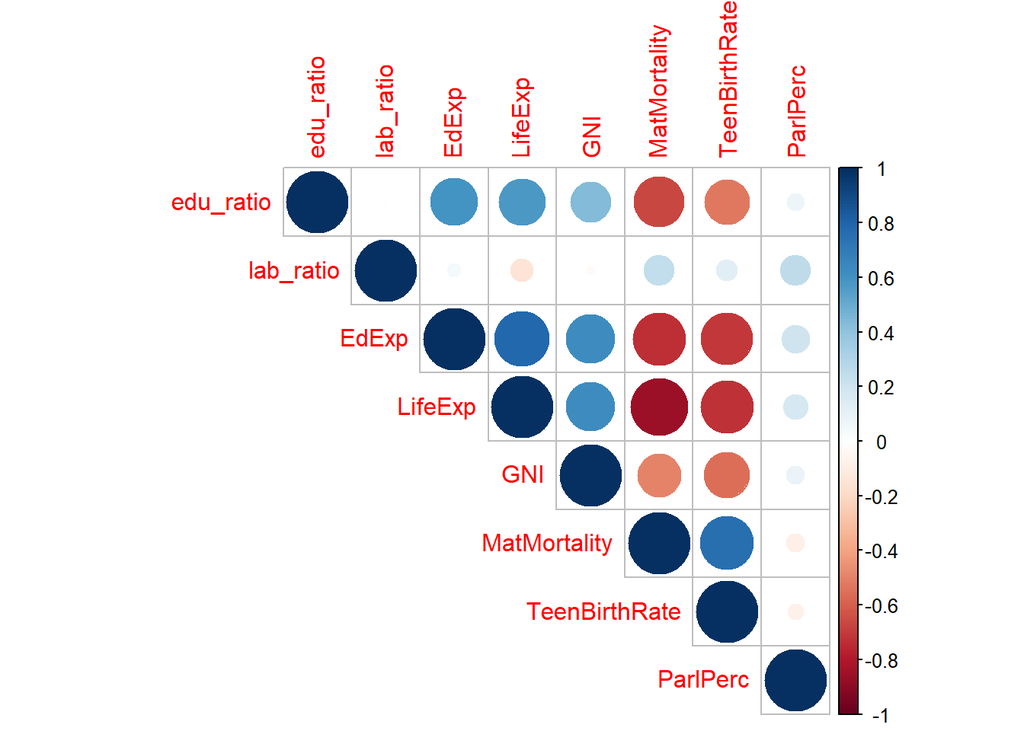

```r
#library(tidyverse)
library(corrplot)
# compute the correlation matrix and visualize it with corrplot
cor(human) %>% corrplot(type = "upper")
```

The correlations can be seen more clearly on a corrplot chart.

Some of the variables in the data are strongly positively or negatively correlated: for instance, maternal mortality has a strong positive correlation with adolescent women giving birth. On the other hand, maternal mortality is strongly negatively correlated with expected education.  
Educational expectations and actualities for females are negatively correlated with maternal mortality and adolescent birth.  
Meanwhile, the ratio of females and males in the labour force and percentage of female representatives in parliament are not strongly correlated with anything. As expected, Gross National income has a positive correlation to expected length of schooling, life expectancy and ratio of women in higher education.

Summary of correlations:  
A strong positive correlation can be seen between TeenBirthRate and MatMortality, EdExp and edu_ratio, EdExp and LifeExp, LifeExp and edu_ratio, LifeExp and EdExp.  
A strong negative correlation can be seen between TeenBirthRate and edu_ratio, TeenBirthRate and LifeExp, TeenBirthRate and EdExp, MatMortality and edu_ratio, MatMortality and LifeExp, MatMortality and EdExp.

We can see that it’s a highly intercorrelated dataset, which is perfect for the purposes of the Principal Component Analysis.

## PCA on non-standardized data

```r
pca_human <- prcomp(human)
pca_human
```

```
## Standard deviations (1, .., p=8):
## [1] 1.854416e+04 1.855219e+02 2.518701e+01 1.145441e+01 3.766241e+00
## [6] 1.565912e+00 1.912052e-01 1.591112e-01
##
## Rotation (n x k) = (8 x 8):
##                         PC1           PC2           PC3           PC4
## edu_ratio     -5.607472e-06  0.0006713951 -3.412027e-05 -2.736326e-04
## lab_ratio      2.331945e-07 -0.0002819357  5.302884e-04 -4.692578e-03
## EdExp         -9.562910e-05  0.0075529759  1.427664e-02 -3.313505e-02
## LifeExp       -2.815823e-04  0.0283150248  1.294971e-02 -6.752684e-02
## GNI           -9.999832e-01 -0.0057723054 -5.156742e-04  4.932889e-05
## MatMortality   5.655734e-03 -0.9916320120  1.260302e-01 -6.100534e-03
## TeenBirthRate  1.233961e-03 -0.1255502723 -9.918113e-01  5.301595e-03
## ParlPerc      -5.526460e-05  0.0032317269 -7.398331e-03 -9.971232e-01
##                         PC5           PC6           PC7           PC8
## edu_ratio     -0.0022935252  2.180183e-02  6.998623e-01  7.139410e-01
## lab_ratio      0.0022190154  3.264423e-02  7.132267e-01 -7.001533e-01
## EdExp          0.1431180282  9.882477e-01 -3.826887e-02  7.776451e-03
## LifeExp        0.9865644425 -1.453515e-01  5.380452e-03  2.281723e-03
## GNI           -0.0001135863 -2.711698e-05 -8.075191e-07 -1.176762e-06
## MatMortality   0.0266373214  1.695203e-03  1.355518e-04  8.371934e-04
## TeenBirthRate  0.0188618600  1.273198e-02 -8.641234e-05 -1.707885e-04
## ParlPerc      -0.0716401914 -2.309896e-02 -2.642548e-03  2.680113e-03
```

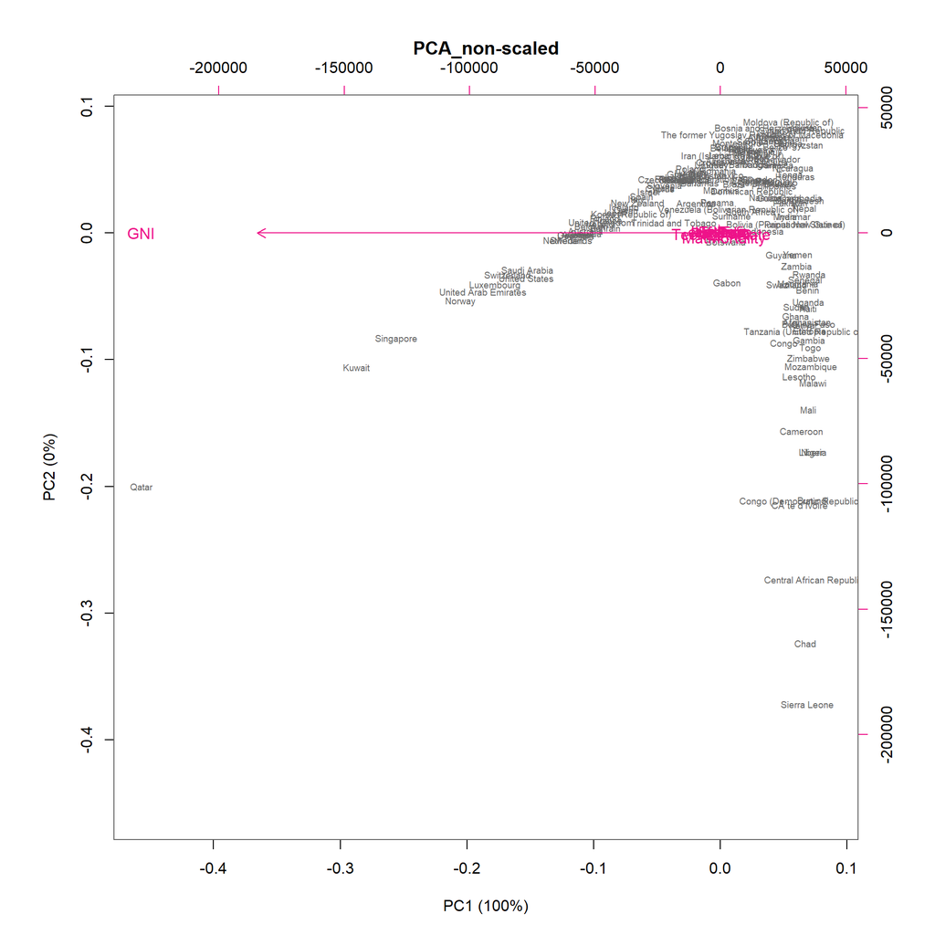

```r
# rounded percentages of variance captured by each PC
s <- summary(pca_human)
pca_pr <- round(100*s$importance[2,], digits = 1)

# create object pc_lab to be used as axis labels
pc_lab <- paste0(names(pca_pr), " (", pca_pr, "%)")

# draw a biplot of the principal component representation and the original variables
biplot(pca_human, choices = 1:2, cex = c(0.6, 1), col = c("grey40", "deeppink2"), xlab = pc_lab[1], ylab = pc_lab[2], main = (title = "PCA_non-scaled"))
```

We can immediately see from the summary of the model and the plot that the first component takes on 100% of the variance. This is due to the difference in ranges of the variables. The GNI per capita is represented by the longest axis, clearly has the biggest standard deviation. All the arrows are sitting on the same axis as if they are fully correlated.

Based on the results below, principal component analysis doesn’t seem to work with unstandardized data.

## PCA on standardized data

Now repeat the analysis, but first standardize data

```r
# standardize the variables
human_std <- scale(human)
summary(human_std)
```

```
##    edu_ratio         lab_ratio           EdExp            LifeExp
##  Min.   :-2.8189   Min.   :-2.6247   Min.   :-2.7378   Min.   :-2.7188
##  1st Qu.:-0.5233   1st Qu.:-0.5484   1st Qu.:-0.6782   1st Qu.:-0.6425
##  Median : 0.3503   Median : 0.2316   Median : 0.1140   Median : 0.3056
##  Mean   : 0.0000   Mean   : 0.0000   Mean   : 0.0000   Mean   : 0.0000
##  3rd Qu.: 0.5958   3rd Qu.: 0.7350   3rd Qu.: 0.7126   3rd Qu.: 0.6717
##  Max.   : 2.6646   Max.   : 1.6632   Max.   : 2.4730   Max.   : 1.4218
##       GNI           MatMortality     TeenBirthRate        ParlPerc
##  Min.   :-0.9193   Min.   :-0.6992   Min.   :-1.1325   Min.   :-1.8203
##  1st Qu.:-0.7243   1st Qu.:-0.6496   1st Qu.:-0.8394   1st Qu.:-0.7409
##  Median :-0.3013   Median :-0.4726   Median :-0.3298   Median :-0.1403
##  Mean   : 0.0000   Mean   : 0.0000   Mean   : 0.0000   Mean   : 0.0000
##  3rd Qu.: 0.3712   3rd Qu.: 0.1932   3rd Qu.: 0.6030   3rd Qu.: 0.6127
##  Max.   : 5.6890   Max.   : 4.4899   Max.   : 3.8344   Max.   : 3.1850
```

```r
pca_human_std <- prcomp(human_std)
pca_human_std
```

```
## Standard deviations (1, .., p=8):
## [1] 2.0708380 1.1397204 0.8750485 0.7788630 0.6619563 0.5363061 0.4589994
## [8] 0.3222406
##
## Rotation (n x k) = (8 x 8):
##                       PC1         PC2         PC3         PC4        PC5
## edu_ratio     -0.35664370  0.03796058 -0.24223089  0.62678110 -0.5983585
## lab_ratio      0.05457785  0.72432726 -0.58428770  0.06199424  0.2625067
## EdExp         -0.42766720  0.13940571 -0.07340270 -0.07020294  0.1659678
## LifeExp       -0.44372240 -0.02530473  0.10991305 -0.05834819  0.1628935
## GNI           -0.35048295  0.05060876 -0.20168779 -0.72727675 -0.4950306
## MatMortality   0.43697098  0.14508727 -0.12522539 -0.25170614 -0.1800657
## TeenBirthRate  0.41126010  0.07708468  0.01968243  0.04986763 -0.4672068
## ParlPerc      -0.08438558  0.65136866  0.72506309  0.01396293 -0.1523699
##                       PC6         PC7         PC8
## edu_ratio      0.17713316  0.05773644  0.16459453
## lab_ratio     -0.03500707 -0.22729927 -0.07304568
## EdExp         -0.38606919  0.77962966 -0.05415984
## LifeExp       -0.42242796 -0.43406432  0.62737008
## GNI            0.11120305 -0.13711838 -0.16961173
## MatMortality   0.17370039  0.35380306  0.72193946
## TeenBirthRate -0.76056557 -0.06897064 -0.14335186
## ParlPerc       0.13749772  0.00568387 -0.02306476
```

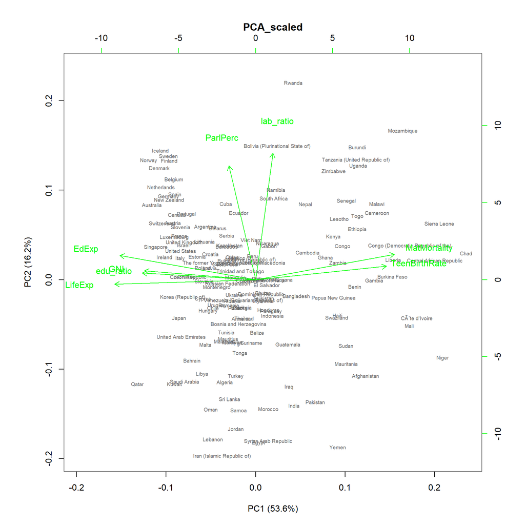

```r
# rounded percentages of variance captured by each PC
s_st <- summary(pca_human_std)
pca_pr_st <- round(100*s_st$importance[2,], digits = 1)

# create object pc_lab to be used as axis labels
pc_lab_st <- paste0(names(pca_pr_st), " (", pca_pr_st, "%)")

# draw a biplot of the principal component representation and the original variables
biplot(pca_human_std, choices = 1:2, cex = c(0.6, 1), col = c("grey40", "green"), xlab = pc_lab_st[1], ylab = pc_lab_st[2], main = (title = "PCA_scaled"))
```

The analysis of the standardized data looks much more reliable. The first component takes 53.6% of the variance, and the second component - 16.2% of the variance. The two components together account for 69.8% of the variance, this number is high enough to use these two first components for the analysis. The countries are distibured throughout the bidimensional space defined by the two principal components. The plot visualizes the relationships of the original features with each other, and with the principal components.  
Arrows pointing to the same direction are positive correlation and the closer they are the stronger the correlation is. Arrows pointing to opposite directions identify negative correlation. The angle between a variable and a PC axis can be interpret as the correlation between the two. The length of the arrows are proportional to the standard deviations of the variables.

Same correlations as described earlier can be seen here.  
The angle between the feature and a PC axis can be interpreted as the correlation between the two. Here, lab_ratio and ParlPerc (percent representation in Parliament) are contributing to the PC2. The ratio of females and males with at least secondary education, expeted years of schooling, life expectancy at birth, Gross National Income per capita, maternal mortality ratio and adolescent birth rate seem to contribute to the PC1.

The variance (proportional to the length of the arrows) seems more or less of the same magnitude for different variables.

**Interpreting the first two principal component dimensions**

Based on these results and how the countries are situated in the biplot, the first principal component seems to capture mostly the wealth of the country. I would suggest to call it ‘wealth’, as because it collects indicators of health, social protection, and economic growth. The variables falling into PC1 describe life expectancy at birth, GNI per capita, maternal maternity ratio, adolescent birth rate, expected years of education, and population with secondary education ratio. All of these parameters support the welfare of a country.

The second component PC2 captures some aspects of gender equality, since it is dealing with workforce gender ratio and the participation rate of women in Parliament, so I suggest to call it ‘equality’.